# Assignment 4: Movie Review Analysis [50 Pt]

In this assignment, we will build a recurrent neural network to work with sequential text data, specificially, movie review data to identify the reviewer sentiment. In the process of completing this assignment, you will:

1. Clean and process text data for machine learning.
2. Perform tokenization of text data.
3. Understand and implement a word-level recurrent neural network.
4. Implement batching of text data using a DataLoader before training a recurrent neural network.
5. Understand how to apply pretrained models for transfer learning in natural language processing projects.

### What to submit

Submit an HTML file containing all your code, outputs, and write-up from parts A and B. You can produce a HTML file directly from Google Colab. The Colab instructions are provided at the end of this document.

**Do not submit any other files produced by your code.**

Include a link to your colab file in your submission.

Please use Google Colab to complete this assignment. If you want to use Jupyter Notebook, please complete the assignment and upload your Jupyter Notebook file to Google Colab for submission.

## Colab Link

Include a link to your Colab file here. If you would like the TA to look at your Colab file in case your solutions are cut off, **please make sure that your Colab file is publicly accessible at the time of submission.**

```python
# TO BE COMPLETED

https://drive.google.com/file/d/1yF8GWDaoiPGIKlnEu_J69DS2LQ8-yLUq/view?usp=sharing
```

# PART A - Sentiment Analysis

In this part we will construct a world-level LSTM model for identifying positive and negative reviews. This will be done in a similar way to what was shared in the preparation code for Assignment 4.

```python
# load standard modules/libraries
import pandas as pd
import numpy as np
import matplotlib.pyplot as plt
import seaborn as sns
from sklearn.model_selection import train_test_split

# load special modules/libraries
import os
import warnings
import nltk
from nltk.corpus import stopwords
nltk.download('stopwords')

from collections import Counter
import string
import re
from tqdm  import tqdm

# load pytorch modules/libraries
import torch
import torch.nn as nn
import torch.nn.functional as F
import torch.optim as optim
from torch.utils.data import TensorDataset,DataLoader
```

## Part 1. Data Cleaning [5 pt]

We will be using the "IMDB Movie Review Dataset" provided on the course website. Download "IMDB Dataset.csv" into your Colab workspace.

### Part (i) [1pt EXPLORATORY]

Open up the file in Python, and examine some examples of positive and negative reviews. Comment on the quality of the data and any challenges you foresee in working with these data. Pick one example of a positive review and one of a negative review to support your comments.

```python
# download IMDB review data

# load dataset
df = pd.read_csv("IMDB Dataset.csv")

# process into data and labels
X = df['review'].values
y = df['sentiment'].values
```

```python
'''

First visualizing the dataset
------------------------------------------
'''

# Display the first few rows of the dataset
df.head()
```

|  | review | sentiment |
| --- | --- | --- |
| 0 | One of the other reviewers has mentioned that ... | positive |
| 1 | A wonderful little production. <br /><br />The... | positive |
| 2 | I thought this was a wonderful way to spend ti... | positive |
| 3 | Basically there's a family where a little boy ... | negative |
| 4 | Petter Mattei's "Love in the Time of Money" is... | positive |

```python
# Display some positive reviews
# ----------------------------------------------

print("Positive Reviews:")
df[df['sentiment'] == 'positive']['review'].head()
```

```
Positive Reviews:
```

```
0    One of the other reviewers has mentioned that ...
1    A wonderful little production. <br /><br />The...
2    I thought this was a wonderful way to spend ti...
4    Petter Mattei's "Love in the Time of Money" is...
5    Probably my all-time favorite movie, a story o...
Name: review, dtype: object
```

```python
# Display some negative reviews
# ----------------------------------------------

print("Negative Reviews:")
df[df['sentiment'] == 'negative']['review'].head()
```

```
Negative Reviews:
```

```
3     Basically there's a family where a little boy ...
7     This show was an amazing, fresh & innovative i...
8     Encouraged by the positive comments about this...
10    Phil the Alien is one of those quirky films wh...
11    I saw this movie when I was about 12 when it c...
Name: review, dtype: object
```

```python
# TO BE COMPLETED

# One positive review to check the data quality
# ----------------------------------------------

df[df['sentiment'] == 'positive']['review'].iloc[1]
```

```
'A wonderful little production. <br /><br />The filming technique is very unassuming- very old-time-BBC fashion and gives a comforting, and sometimes discomforting, sense of realism to the entire piece. <br /><br />The actors are extremely well chosen- Michael Sheen not only "has got all the polari"…
```

```python
# One nagative review to check the data quality
# ----------------------------------------------

df[df['sentiment'] == 'negative']['review'].iloc[1]
```

```
"This show was an amazing, fresh & innovative idea in the 70's when it first aired. The first 7 or 8 years were brilliant, but things dropped off after that. By 1990, the show was not really funny anymore, and it's continued its decline further to the complete waste of time it is today.<br /><br />I…
```

```python
'''
PROVIDE YOUR ANSWER BELOW
-----------------------------------------------------------------------------
One example from each sentiment is shown above to discuss the quality of the
data and challenges. As we can see:

HTML tags like <br /> serve formatting purposes in web content but don't
contribute to the sentiment analysis task. Removing these tags is essential
during data preprocessing to ensure that they don't interfere with sentimen
analysis algorithms.

Special characters such as \ and brackets may indicate formatting or
escape characters. These characters need to be removed or appropriately
handled to avoid misinterpretation by sentiment analysis models.


'''
```

### Part (ii) [1pt EXPLORATORY]

Perform summary statistics on the dataset. What is the average character length of a review? What are the lengths of the longest and shortest reviews?

How many positive reviews and negative reviews are there. Generate a histogram to compare the average character length for positive and negative reviews. Comment on the differences in positive and negative reviews and how that may affect the model you will be using later.

```
Average Character Length: 1309.43
Longest Review Length: 13704
Shortest Review Length: 32
Number of Positive Reviews: 25000
Number of Negative Reviews: 25000
Average Character Length of Positive and Negative Reviews:
sentiment
negative    1294.06436
positive    1324.79768
Name: review_length, dtype: float64
```

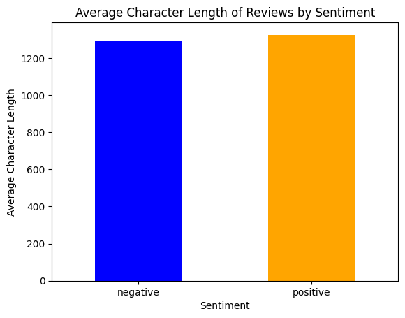

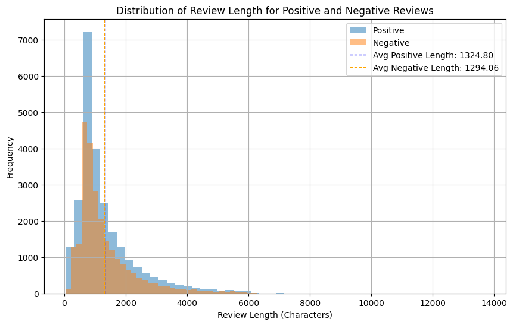

```python
# TO BE COMPLETED

df['review_length'] = df['review'].str.len()
avg_char_length = df['review_length'].mean()
longest_review_length = df['review_length'].max()
shortest_review_length = df['review_length'].min()

print(f"Average Character Length: {avg_char_length:.2f}")
print(f"Longest Review Length: {longest_review_length}")
print(f"Shortest Review Length: {shortest_review_length}")


# Count positive and negative reviews
positive_reviews_count = df[df['sentiment'] == 'positive'].shape[0]
negative_reviews_count = df[df['sentiment'] == 'negative'].shape[0]

print(f"Number of Positive Reviews: {positive_reviews_count}")
print(f"Number of Negative Reviews: {negative_reviews_count}")

# Group by sentiment and calculate the average length
avg_lengths = df.groupby('sentiment')['review_length'].mean()

print("Average Character Length of Positive and Negative Reviews:")
print(avg_lengths)

# Calculate average character length for positive and negative reviews
positive_avg_length = df[df['sentiment'] == 'positive']['review'].apply(len).mean()
negative_avg_length = df[df['sentiment'] == 'negative']['review'].apply(len).mean()



# Create histogram
avg_lengths.plot(kind='bar', color=['blue', 'orange'])
plt.title('Average Character Length of Reviews by Sentiment')
plt.xlabel('Sentiment')
plt.ylabel('Average Character Length')
plt.xticks(rotation=0)
plt.show()

# Generate histogram
plt.figure(figsize=(10, 6))
plt.hist(df[df['sentiment'] == 'positive']['review'].apply(len), bins=50, alpha=0.5, label='Positive')
plt.hist(df[df['sentiment'] == 'negative']['review'].apply(len), bins=50, alpha=0.5, label='Negative')
plt.axvline(positive_avg_length, color='blue', linestyle='dashed', linewidth=1, label=f'Avg Positive Length: {positive_avg_length:.2f}')
plt.axvline(negative_avg_length, color='orange', linestyle='dashed', linewidth=1, label=f'Avg Negative Length: {negative_avg_length:.2f}')
plt.xlabel('Review Length (Characters)')
plt.ylabel('Frequency')
plt.title('Distribution of Review Length for Positive and Negative Reviews')
plt.legend()
plt.grid(True)
plt.show()
```

```python
'''
PROVIDE YOUR ANSWER BELOW
-------------------------------------------------

Average Character Length: 1309.43
Longest Review Length: 13704
Shortest Review Length: 32
Number of Positive Reviews: 25000
Number of Negative Reviews: 25000

Average Character Length of Positive and Negative Reviews:
sentiment
negative    1294.06436
positive    1324.79768
------------------------------------------------------------

General observations :

- Both positive and negative reviews have similar average character lengths
with positive reviews slightly longer on average compared to negative reviews.
However, the difference is relatively small.

While the average lengths are close, there's a notable difference in the range
of review lengths. The longest review is significantly longer than the shortest
one, indicating considerable variability in review lengths within each
sentiment category.

The dataset contains an equal number of positive and negative reviews
which is beneficial for model training as it helps prevent bias towards
any particular sentiment class.


Observations positive vs negative:

While the average lengths are close, it's important to note that individual
reviews vary widely in length within each sentiment category. Some positive
reviews may be longer due to detailed explanations or descriptions
while some negative reviews might be concise but impactful in conveying
dissatisfaction.


The slight difference in average character lengths between positive and
negative reviews, poses a minimal risk of biasing the model towards
considering longer reviews as positive. Given this marginal variance and
the balanced distribution of sentiments in the dataset, it's unlikely to
significantly influence the model's predictions.

---------------------------------------------------------------------



'''
```

### Part (iii) [1pt EXPLORATORY]

The following helper code will be used to process the data before we can train our LSTM model. In point form comment on what processing steps are performed in the code provided below and why these steps are necessary or beneficial to training and LSTM.

```python
X[0]
```

```
"One of the other reviewers has mentioned that after watching just 1 Oz episode you'll be hooked. They are right, as this is exactly what happened with me.<br /><br />The first thing that struck me about Oz was its brutality and unflinching scenes of violence, which set in right from the word GO. Tr…
```

```python
def preprocess_string(str1):
    # remove all non-word characters excluding number and letters
    str1= re.sub(r"[^\w\s]",'',str1)
    # remove all whitespace with no space
    str1= re.sub(r"\s",'',str1)
    # replace digits with no space
    str1= re.sub(r"\d",'',str1)
    return str1

def preprocess_sentence(sen1):
    word_list=[]
    stop_word = set(stopwords.words("english"))
    for word in sen1.lower().split():
        word = preprocess_string(word)
        if word not in stop_word and word!='':
            word_list.append(word)
    return word_list

def get_stoi(data):
    word_list=[]
    for review in data:
        word_list.extend(preprocess_sentence(review))
    corpus = Counter(word_list)
    print(corpus.get)
    # sorting on the basis of most common words
    corpus_ =sorted(corpus,key= corpus.get,reverse=True)[:1000]
    # creating a dict
    stoi =  {ch:i+1 for i,ch in enumerate(corpus_)}
    return stoi

def tokenize(data, labels, stoi):
    # tokenize
    data_encoded = []
    for review in data:
        data_encoded.append([stoi[word] for word in preprocess_sentence(review)
                                     if word in stoi.keys()])

    labels_encoded = [1 if label =='positive' else 0 for label in labels]

    #slight modification after consulting TA in the tutorial
    return data_encoded, np.array(labels_encoded)

def padding_(sentences, seq_len):
    features = np.zeros((len(sentences), seq_len),dtype=int)
    for ii, review in enumerate(sentences):
        if len(review)!=0:
            features[ii, -len(review):] = np.array(review)[:seq_len]

    return features
```

```python
'''
PROVIDE YOUR ANSWER BELOW

preprocess_string function:
  - Removes all non-word characters excluding numbers and letters
    using regular expressions. re.sub()
  - Removes all whitespace characters using regular expressions.
  - Replaces digits with no space using regular expressions.

Necessity:
These steps are necessary to clean the text data and remove any irrelevant
characters or symbols that do not contribute to sentiment analysis.
This preprocessing standardizes the format of the text data, making it
easier for the model to learn.
---------------------------------------------------------------------------

preprocess_sentence function:
  - Converts the input sentence to lowercase.
  - Tokenizes the sentence by splitting it into individual words.
  - Calls preprocess_string to further clean each word as explained earlier in
    the processing_string function (above).
  - Filters out stopwords using the stopwords list.

Necessity:
Lowercasing ensures consistency in word representation,
and tokenization breaks down sentences into manageable words.
Removing stopwords reduces noise by eliminating commonly occurring words that
do not have significant meaning in sentiment analysis.
----------------------------------------------------------------------------

get_stoi function:
  - Constructs a Counter object from the processed word list to
    count the frequency of each word.
  - Sorts the Counter object based on word frequency in descending order
    and selects the top 1000 most common words.
  - Creates a dictionary mapping each word to a unique index.

Necessity:
This function generates a vocabulary that associates each word
in the dataset with a numerical index. Limiting the vocabulary to the most
frequent words reduces the dimensionality of the input space and facilitates
model training by focusing on the most relevant words.
----------------------------------------------------------------------------

tokenize function:
  - Encodes each review by replacing each word with its corresponding
    index in "stoi".
  - Encodes the labels as binary values (1 for positive & 0 for negative).

Necessity:
Encoding the data prepares it for input to the LSTM model,
as networks require numerical input. The encoding ensures that the model
can process the data efficiently.
----------------------------------------------------------------------------

padding_ function:
  - Initializes a zero matrix with dimensions
    (number of sentences, sequence length) for padding.
  - Iterates over each review and pads or truncates it to the specified
    sequence length.

Necessity:
Padding ensures that all input sequences have the same length, which is
necessary for processing in neural networks. This step unifies the
input size.

----------------------------------------------------------------------------



'''
```

### Part (iv) [1pt EXPLORATORY]

Split the dataset into `train`, `valid`, and `test`. Use a 60-20-20 split. Then apply the above processing steps to prepare your data for training.

Set the padding of the reviews to 500.

```python
# TO BE COMPLETED

def split_data(X_pad,y_encoded):
    train, valid, test = [], [], []
    for i, line in enumerate(X_pad):
        if i % 5 < 3:
            train.append((line, y_encoded[i])) # 60% training
        elif i % 5 == 4:
            valid.append((line, y_encoded[i])) # 20% validation
        else:
            test.append((line, y_encoded[i])) # 20% test
    return train, valid, test


# Apply padding
seq_len = 500


stoi = get_stoi(X)
X_en, y_en = tokenize(X, y, stoi)
X_padded = padding_(X_en, seq_len)

train, valid, test = split_data(X_padded,y_en)
```

```
<built-in method get of Counter object at 0x7bf280e8df80>
```

### Part (v) [1pt EXPLORATORY]

Create a DataLoader that will allow you to load the training and validation data in mini-batches. Then generate a dataset of batch size of 16 to verify that the DataLoader works as intended.

```python
# TO BE COMPLETED


train_loader = torch.utils.data.DataLoader(train, batch_size=16, shuffle=True)
valid_loader = torch.utils.data.DataLoader(valid, batch_size=16, shuffle=True)


# verification of the loader
for x,labels in train_loader:
    print(x.shape)
    print(labels.shape)
    break
```

```
torch.Size([16, 500])
torch.Size([16])
```

## Part 2. Model Building [2pt MODEL]

Build a recurrent neural network model, using an architecture of your choosing. Use one or more fully-connected layers to make the prediction based on your recurrent network output.

Instead of using the RNN output value for the final token, another often used strategy is to max-pool over the entire output array. That is, instead of calling something like:

```
out, _ = self.rnn(x)
self.fc(out[:, -1, :])
```

where `self.rnn` is an `nn.RNN`, `nn.GRU`, or `nn.LSTM` module, and `self.fc` is a fully-connected layer, we use:

```
out, _ = self.rnn(x)
self.fc(torch.max(out, dim=1)[0])
```

This works reasonably in practice. An even better alternative is to concatenate the max-pooling and average-pooling of the RNN outputs:

```
out, _ = self.rnn(x)
out = torch.cat([torch.max(out, dim=1)[0],
                 torch.mean(out, dim=1)], dim=1)
self.fc(out)
```

We encourage you to try out all these options. The way you pool the RNN outputs is one of the "hyperparameters" that you can choose to tune later on.

```python
# TO BE COMPLETED

class SentimentRNN(nn.Module):
    def __init__(self, n_input, hidden_size=50, pooling='max'):
        super(SentimentRNN, self).__init__()
        self.name = 'SentimentRNN'
        # Create embedding for input
        self.emb = nn.Embedding(1001, n_input)
        self.hidden_size = hidden_size
        # Feed into RNN
        self.rnn = nn.RNN(n_input, hidden_size, batch_first=True)
        # Feed into fully-connected
        self.fc = nn.Linear(hidden_size * 2 if pooling == 'cat' else hidden_size, 2)
        self.pooling = pooling

    def forward(self, x):
        # Create embedding for input
        x = self.emb(x)
        # Set initial hidden state
        h0 = torch.zeros(1, x.size(0), self.hidden_size)
        # Forward propagate the RNN
        out, _ = self.rnn(x, h0)

        # Apply pooling strategy
        if self.pooling == 'max':
            out_pooled = torch.max(out, dim=1)[0]
        elif self.pooling == 'cat':
            out_max = torch.max(out, dim=1)[0]
            out_avg = torch.mean(out, dim=1)
            out_pooled = torch.cat([out_max, out_avg], dim=1)
        else:  # Default to average pooling
            out_pooled = torch.mean(out, dim=1)

        # Pass the pooled output through the fully-connected layer
        out = self.fc(out_pooled)
        return out
```

## Part 3. Training [3 pt]

### Part (i) [1pt MODEL]

Complete the `get_accuracy` function, which will compute the accuracy (rate) of your model across a dataset (e.g. validation set).

```python
def get_accuracy(model, data):
    """ Compute the accuracy of the `model` across a dataset `data`

    Example usage:

    >>> model = MyRNN() # to be defined
    >>> get_accuracy(model, valid_loader) # the variable `valid_loader` is from above
    """

    # TO BE COMPLETED

    correct, total = 0, 0
    for reviews, labels in data:
        output = model(reviews)
        pred = output.max(1, keepdim=True)[1]
        correct += pred.eq(labels.view_as(pred)).sum().item()
        total += labels.shape[0]
    return correct / total
```

```python
model_max = SentimentRNN(n_input=100, hidden_size=50, pooling='max')

# verifying if the model and function are working fine
get_accuracy(model_max, valid_loader)
```

```
0.4998
```

### Part (ii) [1pt MODEL]

Train your model. Plot the training curve of your final model. Your training curve should have the training/validation loss and accuracy plotted periodically.

```python
# TO BE COMPLETED

def train_rnn_network(model, train, valid, num_epochs=5, learning_rate=1e-5):
    criterion = nn.CrossEntropyLoss()
    op = torch.optim.Adam(model.parameters(), lr=learning_rate)
    losses, train_acc, valid_acc = [], [], []
    epochs = []
    for epoch in range(num_epochs):
        for reviews, labels in train_loader:
            op.zero_grad()
            # reviews = reviews.to(torch.float32)
            pred = model(reviews)
            loss = criterion(pred, labels)

            loss.backward()
            op.step()

        losses.append(float(loss))

        epochs.append(epoch)
        train_acc.append(get_accuracy(model, train_loader))
        valid_acc.append(get_accuracy(model, valid_loader))
        #model_path = get_model_name(model.name, batch, learning_rate, epoch)
        #torch.save(model.state_dict(), model_path)
        print("Epoch %d; Loss %f; Train Acc %f; Val Acc %f" % (
                epoch+1, loss, train_acc[-1], valid_acc[-1]))

    # plotting
    plt.title("Training Curve")
    plt.plot(losses, label="Train")
    plt.xlabel("Epoch")
    plt.ylabel("Loss")
    plt.show()

    plt.title("Training Curve")
    plt.plot(epochs, train_acc, label="Train")
    plt.plot(epochs, valid_acc, label="Validation")
    plt.xlabel("Epoch")
    plt.ylabel("Accuracy")
    plt.legend(loc='best')
    plt.show()
```

```
Epoch 1; Loss 0.693663; Train Acc 0.525200; Val Acc 0.523400
Epoch 2; Loss 0.695998; Train Acc 0.570533; Val Acc 0.563900
Epoch 3; Loss 0.683390; Train Acc 0.599067; Val Acc 0.589900
Epoch 4; Loss 0.683243; Train Acc 0.620667; Val Acc 0.606700
Epoch 5; Loss 0.691771; Train Acc 0.591667; Val Acc 0.578700
```

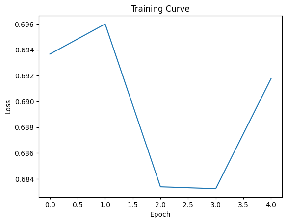

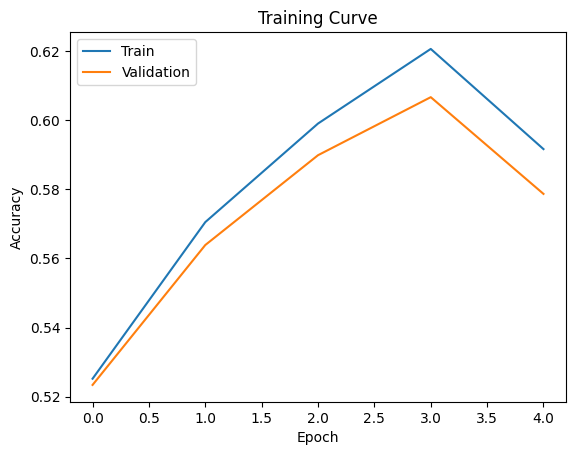

```python
model_max = SentimentRNN(n_input=100, hidden_size=50, pooling='max')

train_rnn_network(model_max, train_loader, valid_loader, num_epochs=5, learning_rate=1e-5)
```